# 2016 Olympics: Hurdles 110m Preview

Matthew Maher

Thursday, August 18, 2016

Quick review of the available data prior to the Rio 2016 110 meter hurdles.

[figure not shown]

The final steps of Omar McLeod’s (center) gold medal race in Rio de Janeiro, Brazil 2016. Dimitri Bascou (left) and Pascal Martinot-Lagarde (right).

Load packages for downloading and preparing athlete data in R:

```r
library(XML)
library(RCurl)
library(dplyr)
```

```r
library(stringr)
library(ggplot2)
```

Read in csv file of web scraped data (scraped August 15th prior to the Rio Olympic Heats/Finals) : https://www.iaaf.org/records/toplists/hurdles/110-metres-hurdles/outdoor/men/senior/2016

```r
a = read.csv("C:/Users/MAHER/Google Drive/R Script Master File/Track110_2016.csv")
str(a)
```

```
## 'data.frame':    185 obs. of  9 variables:
##  $ RANK      : int  1 NA 2 3 NA NA NA 4 NA 5 ...
##  $ MARK      : num  13 13 13 13 13.1 ...
##  $ WIND      : num  1.2 0.4 1 0 1.4 0.7 -0.1 0.2 1 1.4 ...
##  $ COMPETITOR: Factor w/ 166 levels "Aaron MALLETT",..: 110 110 37 112 110 110 110 31 112 58 ...
##  $ DOB       : Factor w/ 165 levels "","1-Feb-86",..: 94 94 18 113 94 94 94 86 113 49 ...
##  $ NAT       : Factor w/ 45 levels "ALG ALG","AUS AUS",..: 26 26 45 15 26 26 26 45 15 26 ...
##  $ POS       : Factor w/ 40 levels "1","1h#","1h1",..: 1 1 1 1 1 1 1 1 1 10 ...
##  $ VENUE     : Factor w/ 85 levels "Al-Kuwait","Alger (SATO)",..: 73 40 27 55 25 27 24 40 30 25 ...
##  $ DATE      : Factor w/ 55 levels "1-Apr-16","10-Jul-16",..: 9 20 54 10 46 37 41 3 31 46 ...
```

```r
summary(a)
```

```
##       RANK            MARK            WIND                  COMPETITOR
##  Min.   :  1.0   Min.   :12.98   Min.   :-1.8000   Orlando ORTEGA:  6
##  1st Qu.: 41.0   1st Qu.:13.38   1st Qu.: 0.2000   Dimitri BASCOU:  5
##  Median : 82.0   Median :13.54   Median : 0.9500   Omar MCLEOD   :  5
##  Mean   : 82.2   Mean   :13.51   Mean   : 0.7625   David OLIVER  :  3
##  3rd Qu.:124.0   3rd Qu.:13.69   3rd Qu.: 1.4000   Aries MERRITT :  2
##  Max.   :161.0   Max.   :13.80   Max.   : 2.0000   Deuce CARTER  :  2
##  NA's   :19                      NA's   :1         (Other)       :162
##         DOB           NAT          POS
##  29-Jul-91:  6   USA USA:53   1      :52
##  20-Jul-87:  5   JAM JAM:15   2      :32
##  25-Apr-94:  5   FRA FRA:14   1r1    :13
##  24-Apr-82:  3   ESP ESP:10   3      :12
##  15-May-92:  2   JPN JPN: 9   1h1    : 7
##  17-Jun-90:  2   BRA BRA: 7   2r1    : 7
##  (Other)  :162   (Other):77   (Other):62
##                            VENUE            DATE
##  Amsterdam (Olympisch Stadion): 13   14-May-16: 16
##  Eugene (Hayward Field), OR   : 12   9-Jul-16 : 13
##  Clermont (NTC), FL           :  9   28-May-16: 11
##  Kingston (NS), JAM           :  7   22-May-16:  9
##  Doha (Hamad Bin Suhaim)      :  5   11-Jun-16:  8
##  Mannheim (Hoffmann)          :  5   23-Apr-16:  8
##  (Other)                      :134   (Other)  :120
```

Parse the data to get it into a workable format. This will include creating variables for age and days since last race. But first…coffee…nah, first we must use the stringr package to parse the variables for Nation and the dates.

```r
a$NAT <- substr(a$NAT,1,3)
a$NAT <- as.factor(a$NAT)

t <- substr(a$DOB, 1,2)
t <- str_replace_all(t, "-" , "")
t2 <- substr(a$DOB, 3,6)
t2 <- str_replace_all(t2, "-", "")
t3 <- substr(a$DOB, 7,9)
t3 <- str_replace_all(t3,"-", "")

# Produce functions to make this all easier

fm  <- function(x) {
  a=x
  a[a=="Jan"] <- "01"
  a[a=="Feb"] <- "02"
  a[a=="Mar"] <- "03"
  a[a=="Apr"] <- "04"
  a[a=="May"] <- "05"
  a[a=="Jun"] <- "06"
  a[a=="Jul"] <- "07"
  a[a=="Aug"] <- "08"
  a[a=="Sep"] <- "09"
  a[a=="Oct"] <- "10"
  a[a=="Nov"] <- "11"
  a[a=="Dec"] <- "12"
  return(a)
}

fy <- function(x){
  a=x
  if(a <20) a1 <- paste("20",a,sep="")
  if(a > 20) a1 <- paste("19",a,sep="")
  return(a1)
}

fd <- function(x) {
  a = x
  a[(a=="1")] <- "01"
  a[(a=="2")] <- "02"
  a[(a=="3")] <- "03"
  a[(a=="4")] <- "04"
  a[(a=="5")] <- "05"
  a[(a=="6")] <- "06"
  a[(a=="7")] <- "07"
  a[(a=="8")] <- "08"
  a[(a=="9")] <- "09"
  return(a)
}

tty <- fy(t3)
ttm <- fm(t2)
ttd <- fd(t)

tt <- paste(tty, ttm, ttd, sep="-")

# Below we calculate Age as of the time this script is run, however you may be more interested in age at the time of the race. If that is the case, you'll need to modify the script as I do with the "Last Race" variable below.

a$DOB <- as.Date(tt, format="%Y-%m-%d")
a$AGE <- as.numeric((Sys.Date()-a$DOB)/365)
```

Calculate how many days it’s been since each race so we can see if they are trending up or down over time (in terms of becoming faster/slower).

```r
ta <- substr(a$DATE, 1,2)
ta <- str_replace_all(ta, "-" , "")

tb <- substr(a$DATE, 3,6)
tb <- str_replace_all(tb, "-", "")

tc <- substr(a$DATE, 7,9)
tc <- str_replace_all(tc,"-", "")

tcy <- fy(tc)
tbm <- fm(tb)
tad <- fd(ta)

ttt <- paste(tcy, tbm, tad, sep="-")
a$DATE <- as.Date(ttt, format="%Y-%m-%d")
a$LastRace <- as.numeric((as.Date("2016-08-17",format="%Y-%m-%d")-a$DATE))

# To get a sense of how many days it has been since the beginning of the year....

as.numeric((as.Date("2016-08-17",format="%Y-%m-%d")-(as.Date("2016-01-01",format="%Y-%m-%d"))))
```

```
## [1] 229
```

Calculate the average time for each individual runner in this year’s data

```r
a1 <- a %>%
  group_by(COMPETITOR, NAT) %>%
  summarise(avgTime=mean(MARK),
            Age=mean(AGE),
            TopTimesRecorded=n(),
            DaysSinceLastRace=min(LastRace)) %>%
  arrange(avgTime)

head(a1,15)
```

```
## Source: local data frame [15 x 6]
## Groups: COMPETITOR [15]
##
##              COMPETITOR    NAT avgTime      Age TopTimesRecorded
##                  (fctr) (fctr)   (dbl)    (dbl)            (int)
## 1         Aaron MALLETT    USA   13.48 21.90959                1
## 2  Abdulaziz AL MANDEEL    KUW   13.51 27.26027                1
## 3    Adarius WASHINGTON    USA   13.40 23.84658                1
## 4          Aleec HARRIS    USA   13.43 25.81644                1
## 5         Alex AL-AMEEN    NGR   13.70 27.48219                1
## 6        Alexander JOHN    GER   13.38 30.31507                1
## 7          Amere LATTIN    USA   13.59 19.11507                1
## 8     Andreas MARTINSEN    DEN   13.65 26.10685                1
## 9          Andrew POZZI    GBR   13.19 24.27671                1
## 10         Andrew RILEY    JAM   13.35 27.96712                1
## 11        Antoine LLOYD    USA   13.69 20.20274                1
## 12       Antonio ALKANA    RSA   13.28 26.36986                1
## 13         Antwon HICKS    NGR   13.27 33.46027                1
## 14        Aries MERRITT    USA   13.23 31.09041                2
## 15           Arnau ERTA    ESP   13.71 24.38630                1
## Variables not shown: DaysSinceLastRace (dbl)
```

Filter our those who have not posted a top race time for the last 228 days (aka, year-to-date prior to the Olympic Games in Rio de Janeiro, Brazil).

```r
aa <- a[a$LastRace<228,]

b <- aa %>%
  group_by(COMPETITOR) %>%
  summarise(avgTime=mean(MARK),
            Age=mean(AGE),
            TopTimes=n(),
            SinceLastRace=min(LastRace)) %>%
  arrange(avgTime)

c <- a %>%
  group_by(COMPETITOR, NAT) %>%
  summarise(unique=n())

c <- c[-3]

d <- merge(b,c)

d <- arrange(d, avgTime)

head(d,15)
```

```
##                 COMPETITOR  avgTime      Age TopTimes SinceLastRace NAT
## 1              Devon ALLEN 13.03000 21.69863        1            39 USA
## 2              Omar MCLEOD 13.03600 22.33151        5            46 JAM
## 3         Hansle PARCHMENT 13.11000 26.18904        2            95 JAM
## 4             David OLIVER 13.12333 34.34247        3            67 USA
## 5           Orlando ORTEGA 13.12833 25.07397        6            24 ESP
## 6  Pascal MARTINOT-LAGARDE 13.17000 24.92329        1            33 FRA
## 7             Andrew POZZI 13.19000 24.27671        1            25 GBR
## 8               Ronnie ASH 13.19500 28.14795        2            39 USA
## 9           Dimitri BASCOU 13.20200 29.10137        5            25 FRA
## 10            Deuce CARTER 13.20500 25.90685        2            46 JAM
## 11           Gregor TRABER 13.21000 23.72603        1            19 GER
## 12             Jeff PORTER 13.21000 30.75068        1            39 USA
## 13           Aries MERRITT 13.23000 31.09041        2            39 USA
## 14          David OMOREGIE 13.25000 20.81096        1            32 GBR
## 15            Jarret EATON 13.25000 27.16986        1            89 USA
```

Also, let’s consider removing a couple top athletes who are not competing in Rio for various reasons (such as Jamaican Hansle Parchment and American David Oliver).

```r
d <- d[d$COMPETITOR!="Hansle PARCHMENT",]
d <- d[d$COMPETITOR!="David OLIVER",]
```

What about a curiosity regarding each national team’s pool of talent and descriptive statistics?

```r
team <- d %>%
  na.omit() %>%
  group_by(NAT) %>%
  summarise(avgTime=mean(avgTime),
            Athletes=n(),
            AvgAge=mean(Age, na.rm=T)) %>%
  arrange(desc(Athletes))

head(team,15)
```

```
## Source: local data frame [15 x 4]
##
##       NAT  avgTime Athletes   AvgAge
##    (fctr)    (dbl)    (int)    (dbl)
## 1     USA 13.55543       47 24.81521
## 2     FRA 13.47620       10 24.34329
## 3     JPN 13.67889        9 23.43288
## 4     JAM 13.43512        8 23.37534
## 5     BRA 13.67286        7 25.00157
## 6     GBR 13.45143        7 25.08571
## 7     GER 13.45500        6 27.17763
## 8     ESP 13.51367        5 24.45370
## 9     CAN 13.54500        4 25.50411
## 10    CHN 13.53500        4 24.07466
## 11    RSA 13.58500        4 25.73493
## 12    BAR 13.64667        3 25.66393
## 13    BEL 13.74333        3 27.83014
## 14    CUB 13.51667        3 23.42192
## 15    ITA 13.57667        3 25.84932
```

If we look at the dataset “d”, we get a sense of some of the Elite runners in this year’s group.

Competitor NAT AvgTime Number of Races

Devon ALLEN USA 13.03000 1

Omar MCLEOD JAM 13.03600 5

Orlando ORTEGA ESP 13.12833 6

Pascal MARTINOT-LAGARDE FRA 13.17000 1

Andrew POZZI GBR 13.19000 1

Ronnie ASH USA 13.19500 2

Dimitri BASCOU FRA 13.20200 5

Deuce CARTER JAM 13.20500 2

Gregor TRABER GER 13.21000 1

Jeff PORTER USA 13.21000 1

Keep in mind that McLeod has truthfully run the fastest times this year, however Allen has only one data point in this sample and it’s rather fast at 13.03 seconds.

```r
elites <- a[a$COMPETITOR=="Devon ALLEN" |a$COMPETITOR=="Omar MCLEOD" |
              a$COMPETITOR=="Orlando ORTEGA" |a$COMPETITOR=="Ronnie ASH" |
              a$COMPETITOR=="Pascal MARTINOT-LAGARDE" |a$COMPETITOR=="Dimitri BASCOU" |
              a$COMPETITOR=="Andrew POZZI" |a$COMPETITOR=="Deuce CARTER" |
              a$COMPETITOR=="Gregor TRABER" |a$COMPETITOR=="Jeff PORTER",]

summary(elites)
```

```
##       RANK            MARK            WIND                 COMPETITOR
##  Min.   : 1.00   Min.   :12.98   Min.   :-1.000   Orlando ORTEGA:6
##  1st Qu.: 3.75   1st Qu.:13.08   1st Qu.: 0.000   Dimitri BASCOU:5
##  Median : 7.50   Median :13.17   Median : 0.700   Omar MCLEOD   :5
##  Mean   : 6.80   Mean   :13.14   Mean   : 0.604   Deuce CARTER  :2
##  3rd Qu.: 9.75   3rd Qu.:13.21   3rd Qu.: 1.200   Ronnie ASH    :2
##  Max.   :11.00   Max.   :13.25   Max.   : 1.800   Andrew POZZI  :1
##  NA's   :15                                       (Other)       :4
##       DOB                  NAT         POS
##  Min.   :1985-11-25   JAM    :7   1      :13
##  1st Qu.:1988-07-02   ESP    :6   2      : 5
##  Median :1991-07-29   FRA    :6   1h1    : 3
##  Mean   :1991-01-02   USA    :4   3      : 3
##  3rd Qu.:1992-12-02   GBR    :1   1sf3   : 1
##  Max.   :1994-12-12   GER    :1   1h#    : 0
##                       (Other):0   (Other): 0
##                            VENUE        DATE                 AGE
##  Eugene (Hayward Field), OR   :4   Min.   :2016-04-30   Min.   :21.70
##  Kingston (NS), JAM           :3   1st Qu.:2016-06-02   1st Qu.:23.73
##  Monaco (Stade Louis II)      :3   Median :2016-07-02   Median :25.07
##  Amsterdam (Olympisch Stadion):2   Mean   :2016-06-23   Mean   :25.64
##  Doha (Hamad Bin Suhaim)      :2   3rd Qu.:2016-07-15   3rd Qu.:28.15
##  London (Olympic Stadium)     :2   Max.   :2016-07-29   Max.   :30.75
##  (Other)                      :9
##     LastRace
##  Min.   : 19.00
##  1st Qu.: 33.00
##  Median : 46.00
##  Mean   : 54.96
##  3rd Qu.: 76.00
##  Max.   :109.00
##
```

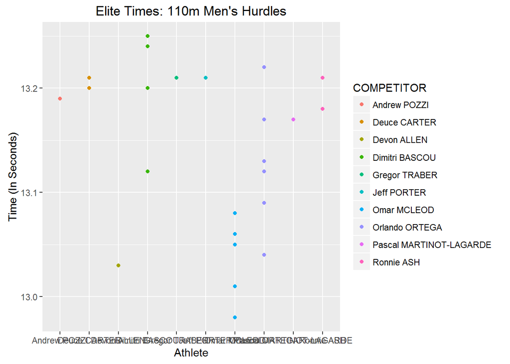

```r
g <- ggplot(elites, aes(y=MARK, x=COMPETITOR, colour=COMPETITOR)) + geom_point(stat="identity")
g <- g + ggtitle("Elite Times: 110m Men's Hurdles")+labs(y="Time (In Seconds)", x="Athlete")
```

In this initial graphic we see that there seems to be a threshold at 13.1 seconds that only three or four athletes appear to cross in 2016.

```r
medal <- a[a$COMPETITOR=="Devon ALLEN" |a$COMPETITOR=="Omar MCLEOD" |
             a$COMPETITOR=="Orlando ORTEGA" | a$COMPETITOR=="Dimitri BASCOU",]

summary(medal)
```

```
##       RANK           MARK            WIND
##  Min.   :1.00   Min.   :12.98   Min.   :-1.0000
##  1st Qu.:1.75   1st Qu.:13.05   1st Qu.: 0.0000
##  Median :2.50   Median :13.12   Median : 0.7000
##  Mean   :3.00   Mean   :13.12   Mean   : 0.5941
##  3rd Qu.:3.75   3rd Qu.:13.20   3rd Qu.: 1.2000
##  Max.   :6.00   Max.   :13.25   Max.   : 1.7000
##  NA's   :13
##                 COMPETITOR      DOB                  NAT         POS
##  Orlando ORTEGA      :6    Min.   :1987-07-20   ESP    :6   1      :12
##  Dimitri BASCOU      :5    1st Qu.:1987-07-20   FRA    :5   2      : 2
##  Omar MCLEOD         :5    Median :1991-07-29   JAM    :5   1h1    : 1
##  Devon ALLEN         :1    Mean   :1991-05-24   USA    :1   1sf3   : 1
##  Aaron MALLETT       :0    3rd Qu.:1994-04-25   ALG    :0   3      : 1
##  Abdulaziz AL MANDEEL:0    Max.   :1994-12-12   AUS    :0   1h#    : 0
##  (Other)             :0                         (Other):0   (Other): 0
##                             VENUE        DATE                 AGE
##  Amsterdam (Olympisch Stadion) :2   Min.   :2016-04-30   Min.   :21.70
##  Doha (Hamad Bin Suhaim)       :2   1st Qu.:2016-05-22   1st Qu.:22.33
##  Eugene (Hayward Field), OR    :2   Median :2016-06-26   Median :25.07
##  Monaco (Stade Louis II)       :2   Mean   :2016-06-16   Mean   :25.25
##  Angers                        :1   3rd Qu.:2016-07-09   3rd Qu.:29.10
##  Des Moines (Drake Stadium), IA:1   Max.   :2016-07-24   Max.   :29.10
##  (Other)                       :7
##     LastRace
##  Min.   : 24.00
##  1st Qu.: 39.00
##  Median : 52.00
##  Mean   : 61.12
##  3rd Qu.: 87.00
##  Max.   :109.00
##
```

Now let’s take a look at a couple of graphics, one looking at the larger elites field and the other at those we expect to medal.

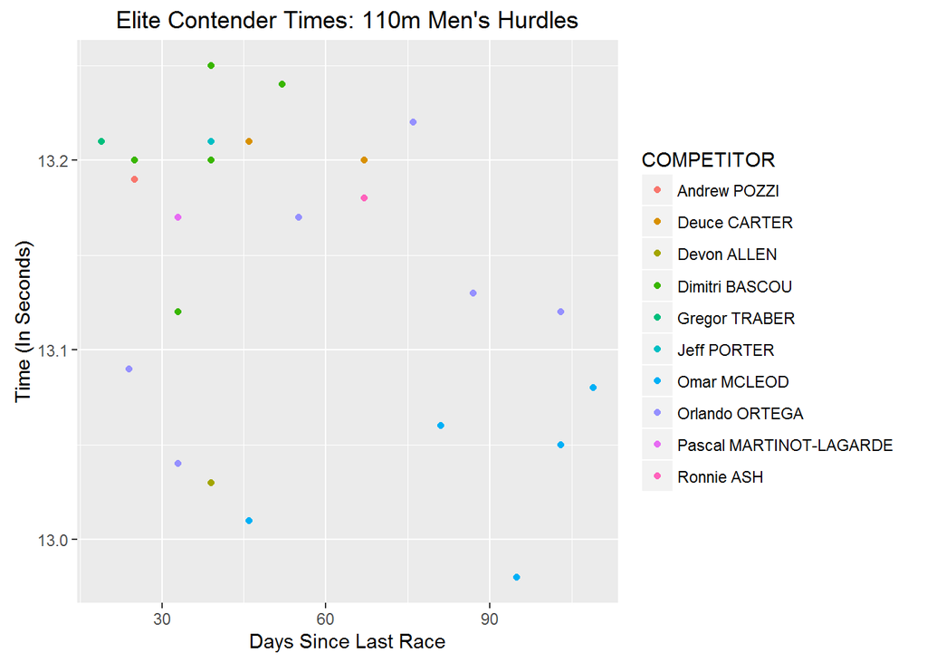

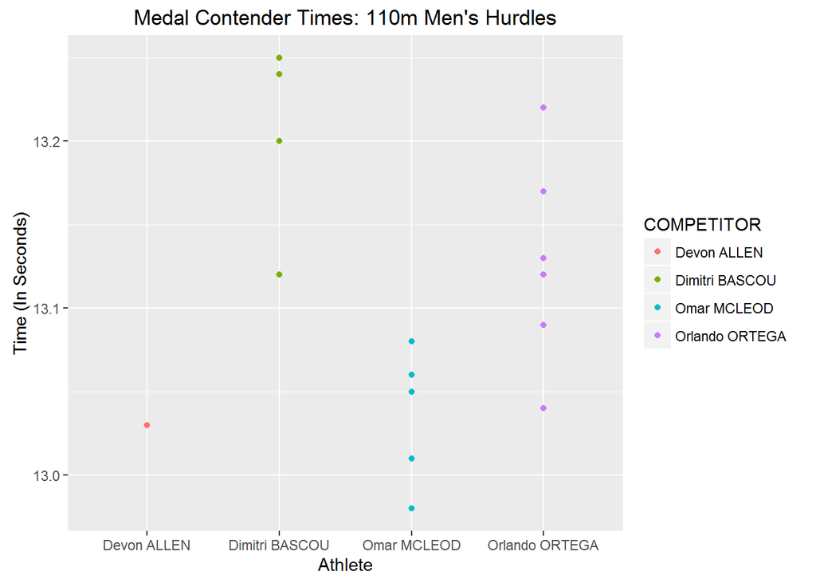

My prediction looking at this data is that 1-4 are:

GOLD Omar McLeod (Jamaica)

SILVER Orlando Ortega (Spain)

BRONZE Dimitri Bascou (France) | OR | Devon Allen (USA) | OR | Pascal Martinot-Lagarde (France)

My confidence in Gold and Silver is much higher than Bronze. Bronze I’d predict is a toss up.

My reasoning for not putting a lot of confidence in Allen is that he’s young, inexperienced on this stage, and only has one recorded time in this data set. McLeod and Ortega are consistently fast in this data. Lastly, Ortega and Pascal Martinot-Lagarde are physically gifted in their height and build for this event. I suspect they will have a better time running down the hurldes than the others. However, McLeod, Bascou and Allen are just blazing fast guys that can hit half the hurldes and still steal the race.

Final results of the race can be found here: http://results.nbcolympics.com/track-field/event/men-110m-hurdles/index.html

Thanks for reading!